# Assignment 5

Jenny Norton

9/19/2020

## Assignment 5

Load “Tidyverse” library.

```r
library(tidyverse)
```

## Question 1

For this problem, you will use readr to load the data you selected for Project 1. Write an appropriate read_csv command, using explicitly given col_ types to read the data, as we did in class.

Get the pathname to the file with the `here` package:

```r
library(here)
ufo_data_path <- here("Project1Data", "ufodata.csv")
```

Note: This indicates your data file was in a subfolder of the project called “Project1Data”. It wasn’t, so I moved it into that folder in the repo.

Read it in with `readr`

```r
ufo_data <- read_csv(ufo_data_path)
```

Let’s fix the columns. I’m going to change date_documented to a date field. Also the date_time column but I’ll wait until we learn more about date and time and I’ll leave it character for now.

```r
ufo_data <- read_csv(ufo_data_path,
                     col_types =
                       cols(
  Date_time = col_character(),
  city = col_character(),
  `state/province` = col_character(),
  country = col_character(),
  UFO_shape = col_character(),
  length_of_encounter_seconds = col_double(),
  described_duration_of_encounter = col_character(),
  description = col_character(),
  date_documented = col_date (format = "%m/%d/%Y %*"),
  latitude = col_double(),
  longitude = col_double()
)
)
```

I have a parsing failure in latitude and length_of_encounter due to a trailing character but I won’t worry about that now because there aren’t that many.

## Question 2

Now that you have your data imported, select one variable in your data set, and perform a (very basic and preliminary) exploratory analysis of that variable. You might produce a graph of the distribution, or produce some summary statistics, or make a table.

I want to see what shapes and how many of each are in the UFO_shape column.

```r
ufo_data %>%
  count(UFO_shape)
```

```
## # A tibble: 30 x 2
##    UFO_shape     n
##    <chr>     <int>
##  1 changed       1
##  2 changing   1962
##  3 chevron     952
##  4 cigar      2057
##  5 circle     7608
##  6 cone        316
##  7 crescent      2
##  8 cross       233
##  9 cylinder   1283
## 10 delta         7
## # … with 20 more rows
```

I’d sort this by size–or even limit to large sizes:

```r
ufo_data %>%
  count(UFO_shape) %>%
  filter(n>500) %>%
  arrange(desc(n))
```

```
## # A tibble: 20 x 2
##    UFO_shape     n
##    <chr>     <int>
##  1 light     16565
##  2 triangle   7865
##  3 circle     7608
##  4 fireball   6208
##  5 other      5649
##  6 unknown    5584
##  7 sphere     5387
##  8 disk       5213
##  9 oval       3733
## 10 formation  2457
## 11 cigar      2057
## 12 changing   1962
## 13 <NA>       1932
## 14 flash      1328
## 15 rectangle  1297
## 16 cylinder   1283
## 17 diamond    1178
## 18 chevron     952
## 19 egg         759
## 20 teardrop    750
```

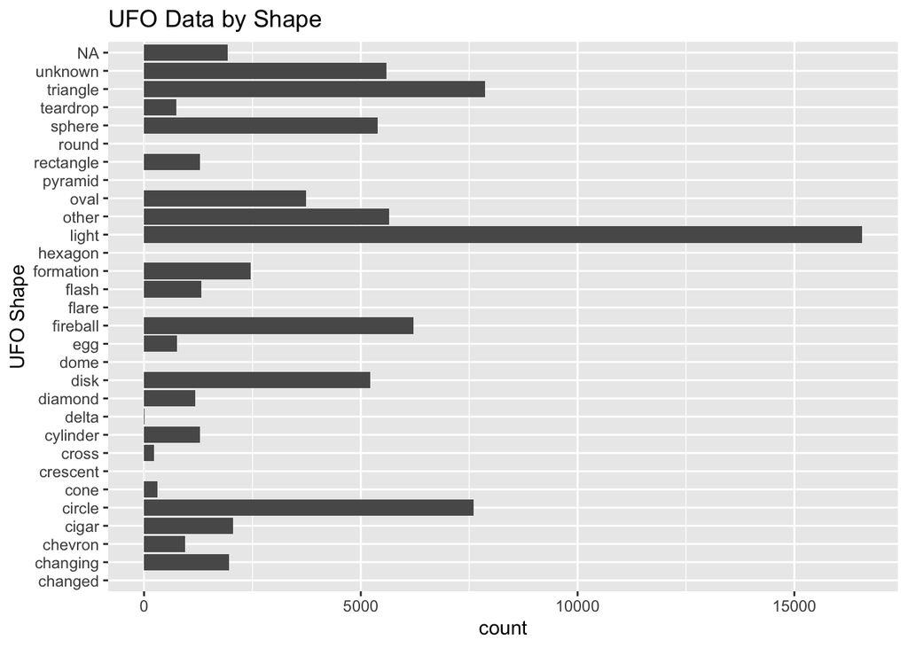

```r
ggplot(ufo_data) +
    geom_bar(aes(x = UFO_shape)) +
               coord_flip() +
  labs(title = "UFO Data by Shape", x = "UFO Shape")
```

This is probably also worth restricting the rare ones out. I also got rid of the NAs:

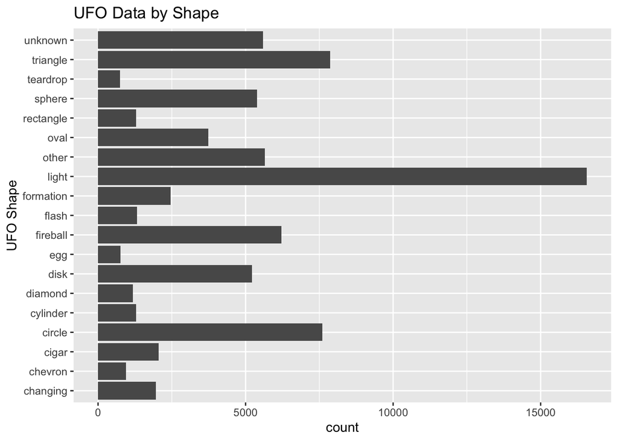

```r
ufo_data %>%
  group_by(UFO_shape) %>%
  mutate(shape_count = n()) %>%
  filter(shape_count > 500, !is.na(UFO_shape)) %>%
  ungroup() %>%
ggplot() +
    geom_bar(aes(x = UFO_shape)) +
               coord_flip() +
  labs(title = "UFO Data by Shape", x = "UFO Shape")
```

## Question 3

Now select two variables in your data set, and examine the covariation between them. Again, you might use a graph, a table, or something else to explore the relationship. Describe the relationship you find. If anything requires cleaning before your analysis, perform that step as well, and mention it.

```r
colnames(ufo_data)
```

```
##  [1] "Date_time"                       "city"
##  [3] "state/province"                  "country"
##  [5] "UFO_shape"                       "length_of_encounter_seconds"
##  [7] "described_duration_of_encounter" "description"
##  [9] "date_documented"                 "latitude"
## [11] "longitude"
```

Let’s see the State the sighting happened.

```r
table(ufo_data$`state/province`)
```

```
##
##   ab   ak   al   ar   az   bc   ca   co   ct   dc   de   fl   ga   hi   ia   id
##  333  354  691  666 2689  788 9655 1505  968   99  183 4200 1347  353  707  554
##   il   in   ks   ky   la   ma   mb   md   me   mi   mn   mo   ms   mt   nb   nc
## 2645 1386  653  914  598 1358  155  911  633 2071 1081 1576  415  510  116 1869
##   nd   ne   nf   nh   nj   nm   ns   nt   nv   ny   oh   ok   on   or   pa   pe
##  138  405   25  535 1512  815  143   20  905 3219 2425  766 1584 1845 2582   17
##   pq   pr   qc   ri   sa   sc   sd   sk   tn   tx   ut   va   vt   wa   wi   wv
##   90   33  178  290   30 1076  196   98 1193 3677  743 1393  307 4268 1333  486
##   wy   yk   yt
##  205    7   13
```

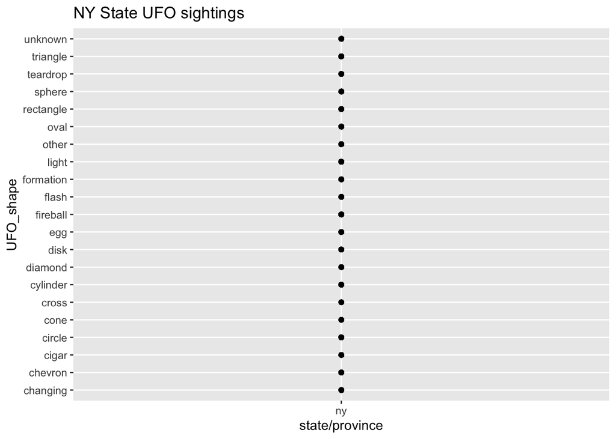

```r
ufo_data %>%
  filter(!is.na(UFO_shape), !is.na(`state/province`), `state/province` == "ny") %>%
  ggplot((aes(x = `UFO_shape`, y = `state/province`))) +
  geom_point() +
  geom_smooth(method = "lm", se = FALSE) +
  coord_flip() +
  labs(title = "NY State UFO sightings")
```

I’m not sure why this isn’t doing what I want. I wanted to see the number of UFO Sightings in NY distributed by UFO Shape.

If you’re wanting a dot plot for shape counts, you’ll need a count value. You could generate one using a mutate and then pass to ggplot:

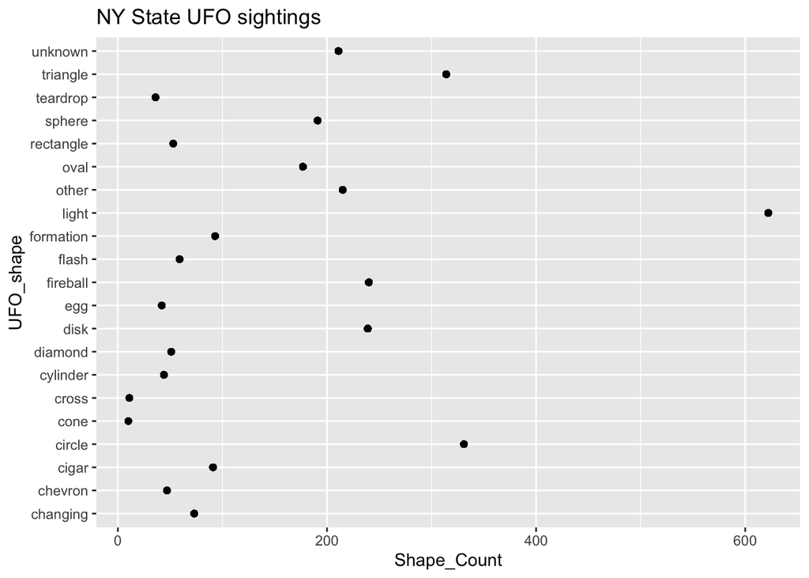

```r
ufo_data %>%
  filter(!is.na(UFO_shape), !is.na(`state/province`), `state/province` == "ny") %>%
  group_by(UFO_shape) %>%
  mutate(Shape_Count = n()) %>%
  ungroup() %>%
  ggplot((aes(x = UFO_shape, y = Shape_Count))) +
  geom_point() +
  coord_flip()  +
  labs(title = "NY State UFO sightings")
```

(Also, a smoother here doesn’t make sense.)

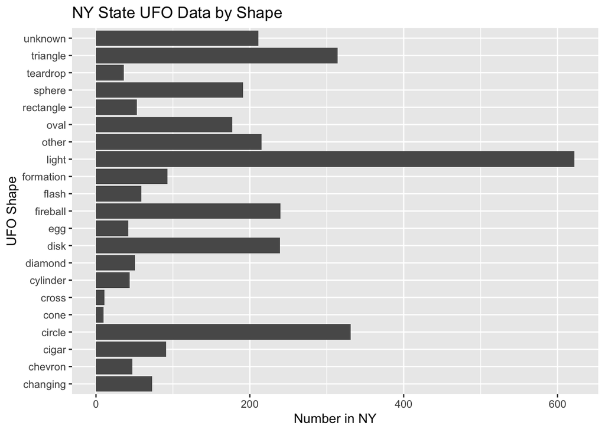

```r
ufo_data %>%
  filter(!is.na(UFO_shape), !is.na(`state/province`), `state/province` == "ny") %>%
ggplot() +
      geom_bar(aes(x = UFO_shape)) +
               coord_flip() +
  labs(title = "NY State UFO Data by Shape", x = "UFO Shape", y = "Number in NY")
```

That looks better!